# arboles de decisiones

Los árboles de decisión son una técnica popular y poderosa en el campo del aprendizaje automático y la inteligencia artificial que se utiliza para la clasificación y la regresión.

un árbol de decisión es una estructura de árbol en la que cada nodo interno representa una “decisión” basada en una característica o atributo del conjunto de datos, y cada hoja representa el resultado de una decisión.

la siguiente data contiene 768 observaciones que se observan 9 variables, a partir de estas variables se clasifica cada observación como negativo o positivo para diabetes

```r
data
```

|  | pregnant | glucose | pressure | triceps | insulin | mass | pedigree | age | diabetes |
| --- | --- | --- | --- | --- | --- | --- | --- | --- | --- |
| 1 | 6 | 148 | 72 | 35 | 0 | 33.6 | 0.627 | 50 | pos |
| 2 | 1 | 85 | 66 | 29 | 0 | 26.6 | 0.351 | 31 | neg |
| 3 | 8 | 183 | 64 | 0 | 0 | 23.3 | 0.672 | 32 | pos |
| 4 | 1 | 89 | 66 | 23 | 94 | 28.1 | 0.167 | 21 | neg |
| 5 | 0 | 137 | 40 | 35 | 168 | 43.1 | 2.288 | 33 | pos |
| 6 | 5 | 116 | 74 | 0 | 0 | 25.6 | 0.201 | 30 | neg |
| 7 | 3 | 78 | 50 | 32 | 88 | 31.0 | 0.248 | 26 | pos |
| 8 | 10 | 115 | 0 | 0 | 0 | 35.3 | 0.134 | 29 | neg |
| 9 | 2 | 197 | 70 | 45 | 543 | 30.5 | 0.158 | 53 | pos |
| 10 | 8 | 125 | 96 | 0 | 0 | 0.0 | 0.232 | 54 | pos |

[output cut: 758 more lines]

Dividimos en 80% y 20% la data, para entrenamiento y test.

```r
ind<-sample(2,nrow(PimaIndiansDiabetes),replace = TRUE, prob = c(0.8,0.2)) #80% entrenamiento, 20% teste


entrenamiento<-PimaIndiansDiabetes[ind==1,]
test<-PimaIndiansDiabetes[ind==2,]
```

nuestra data de entrenamiento será

```r
entrenamiento
```

|  | pregnant | glucose | pressure | triceps | insulin | mass | pedigree | age | diabetes |
| --- | --- | --- | --- | --- | --- | --- | --- | --- | --- |
| 1 | 6 | 148 | 72 | 35 | 0 | 33.6 | 0.627 | 50 | pos |
| 2 | 1 | 85 | 66 | 29 | 0 | 26.6 | 0.351 | 31 | neg |
| 3 | 8 | 183 | 64 | 0 | 0 | 23.3 | 0.672 | 32 | pos |
| 5 | 0 | 137 | 40 | 35 | 168 | 43.1 | 2.288 | 33 | pos |
| 6 | 5 | 116 | 74 | 0 | 0 | 25.6 | 0.201 | 30 | neg |
| 7 | 3 | 78 | 50 | 32 | 88 | 31.0 | 0.248 | 26 | pos |
| 8 | 10 | 115 | 0 | 0 | 0 | 35.3 | 0.134 | 29 | neg |
| 9 | 2 | 197 | 70 | 45 | 543 | 30.5 | 0.158 | 53 | pos |
| 10 | 8 | 125 | 96 | 0 | 0 | 0.0 | 0.232 | 54 | pos |
| 11 | 4 | 110 | 92 | 0 | 0 | 37.6 | 0.191 | 30 | neg |

[output cut: 604 more lines]

nuestra data de test será

```r
test
```

|  | pregnant | glucose | pressure | triceps | insulin | mass | pedigree | age | diabetes |
| --- | --- | --- | --- | --- | --- | --- | --- | --- | --- |
| 4 | 1 | 89 | 66 | 23 | 94 | 28.1 | 0.167 | 21 | neg |
| 14 | 1 | 189 | 60 | 23 | 846 | 30.1 | 0.398 | 59 | pos |
| 15 | 5 | 166 | 72 | 19 | 175 | 25.8 | 0.587 | 51 | pos |
| 16 | 7 | 100 | 0 | 0 | 0 | 30.0 | 0.484 | 32 | pos |
| 25 | 11 | 143 | 94 | 33 | 146 | 36.6 | 0.254 | 51 | pos |
| 26 | 10 | 125 | 70 | 26 | 115 | 31.1 | 0.205 | 41 | pos |
| 31 | 5 | 109 | 75 | 26 | 0 | 36.0 | 0.546 | 60 | neg |
| 38 | 9 | 102 | 76 | 37 | 0 | 32.9 | 0.665 | 46 | pos |
| 42 | 7 | 133 | 84 | 0 | 0 | 40.2 | 0.696 | 37 | neg |
| 44 | 9 | 171 | 110 | 24 | 240 | 45.4 | 0.721 | 54 | pos |

[output cut: 144 more lines]

utilizamos el paquete rpart para modelar nuestro árbol de decisión

```r
arbol4<-rpart(formula = diabetes~pregnant+glucose+pressure+triceps+insulin+mass+pedigree+age,
             data=entrenamiento, method = 'class')
```

el diagrama del árbol de decisión

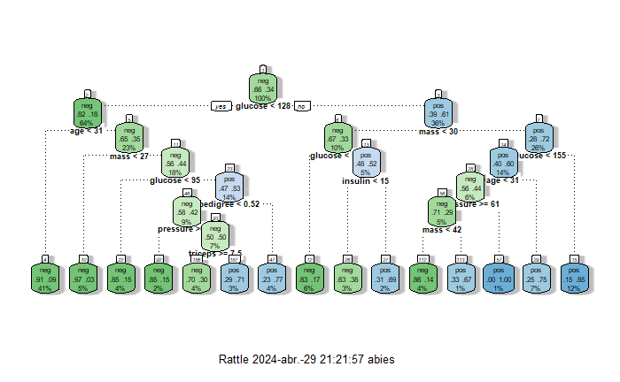

```r
fancyRpartPlot(arbol4,type=2,digits = -2,box.palette = "RdYlBu",  # Paleta de colores para los nodos
               yesno = 1,split.cex = 1.1,cex=0.53)#este
```

podemos realizar un pre podado de nuestro árbol

```r
control.poda<-rpart.control(maxdepth = 5,minsplit = 10)

arbol<-rpart(formula = diabetes~pregnant+glucose+pressure+triceps+insulin+mass+pedigree+age,
             data=entrenamiento, method = 'class', control = control.poda)
```

el diagrama del árbol pre podado es

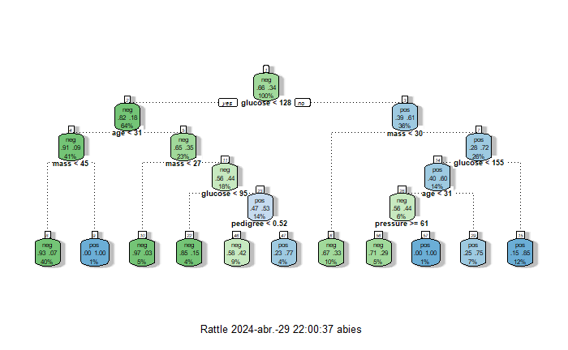

```r
fancyRpartPlot(arbol,type=2,digits = -2,box.palette = "RdYlBu",  # Paleta de colores para los nodos
               yesno = 1,split.cex = 1.1,cex=0.53)
```

ahora hacemos predicciones con los nuestra Data Test

```r
testpredic_arbol<-predict(arbol,newdata=test,type="class")
```

veamos ahora que tan efectivo es nuestro modelo

```r
dia_predic<-data.frame(cbind(PimaIndiansDiabetes,predic_arbol))
dia_predic
```

|  | pregnant | glucose | pressure | triceps | insulin | mass | pedigree | age | diabetes | predic_arbol |
| --- | --- | --- | --- | --- | --- | --- | --- | --- | --- | --- |
| 1 | 6 | 148 | 72 | 35 | 0 | 33.6 | 0.627 | 50 | pos | pos |
| 2 | 1 | 85 | 66 | 29 | 0 | 26.6 | 0.351 | 31 | neg | neg |
| 3 | 8 | 183 | 64 | 0 | 0 | 23.3 | 0.672 | 32 | pos | neg |
| 4 | 1 | 89 | 66 | 23 | 94 | 28.1 | 0.167 | 21 | neg | neg |
| 5 | 0 | 137 | 40 | 35 | 168 | 43.1 | 2.288 | 33 | pos | pos |
| 6 | 5 | 116 | 74 | 0 | 0 | 25.6 | 0.201 | 30 | neg | neg |
| 7 | 3 | 78 | 50 | 32 | 88 | 31.0 | 0.248 | 26 | pos | neg |
| 8 | 10 | 115 | 0 | 0 | 0 | 35.3 | 0.134 | 29 | neg | neg |
| 9 | 2 | 197 | 70 | 45 | 543 | 30.5 | 0.158 | 53 | pos | pos |
| 10 | 8 | 125 | 96 | 0 | 0 | 0.0 | 0.232 | 54 | pos | neg |

[output cut: 758 more lines]

crearemos nuestra matriz de confusión para nuestro árbol

```r
table(testpredic_arbol2,test$diabetes)
```

```
testpredic_arbol2 neg pos
              neg  76  22
              pos  16  40
```

ahora la matriz de confusión para nuestro árbol pre podado

```r
table(testpredic_arbol,test$diabetes)
```

```
testpredic_arbol neg pos
             neg  77  26
             pos  15  36
```

ahora hacemos la predicción para él, un solo dato de la Data Test para nuestro árbol de decisión

```r
predict(arbol4,newdata = data.frame(pregnant=3,glucose=123,pressure=100,triceps=35,insulin=240,mass=57.3,pedigree=0.880,age=22)
        ,type="class")
```

```
  1
neg
Levels: neg pos
```

ahora para nuestro árbol pre podado

```r
predict(arbol,newdata = data.frame(pregnant=3,glucose=123,pressure=100,triceps=35,insulin=240,mass=57.3,pedigree=0.880,age=22)
        ,type="class")
```

```
  1
pos
Levels: neg pos
```

ahora veremos la poda de complejidad de costos de nuestro árbol de decisión

```r
table4
```

```
          CP nsplit rel error    xerror       xstd
1 0.23300971      0 1.0000000 1.0000000 0.05679529
2 0.10679612      1 0.7669903 0.8058252 0.05342465
3 0.02103560      2 0.6601942 0.7378641 0.05191482
4 0.01699029      5 0.5970874 0.7330097 0.05179974
5 0.01456311     11 0.4854369 0.7524272 0.05225415
6 0.01213592     12 0.4708738 0.7524272 0.05225415
7 0.01000000     14 0.4466019 0.7524272 0.05225415
```

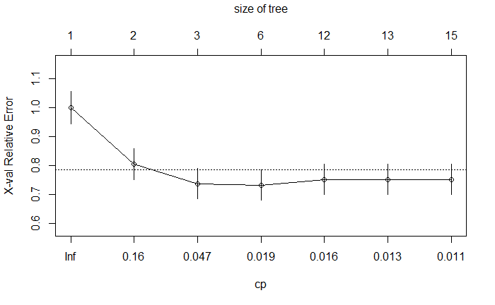

```r
plotcp(arbol4)
```

ahora la poda de complejidad de costos para nuestro árbol pre podado

```r
table
```

```
          CP nsplit rel error    xerror       xstd
1 0.23300971      0 1.0000000 1.0000000 0.05679529
2 0.10679612      1 0.7669903 0.8252427 0.05382258
3 0.02103560      2 0.6601942 0.7669903 0.05258472
4 0.01747573      5 0.5970874 0.7621359 0.05247549
5 0.01000000     10 0.5097087 0.6990291 0.05096579
```

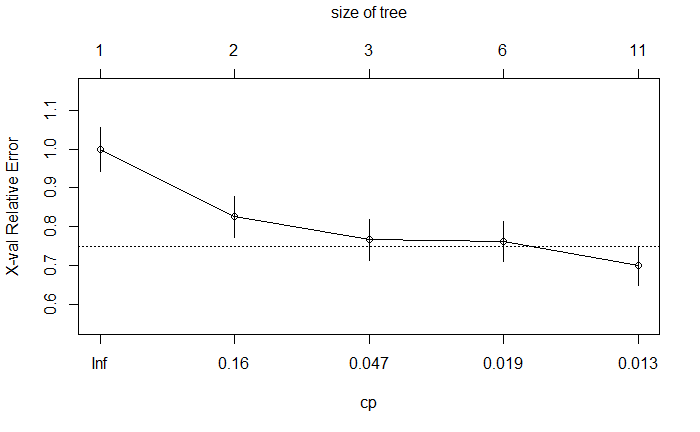

```r
plotcp(arbol)
```

ahora podemos hacer un post podado

```r
Arbolp<-prune(arbol4,arbol$cptable[4,"CP"])
```

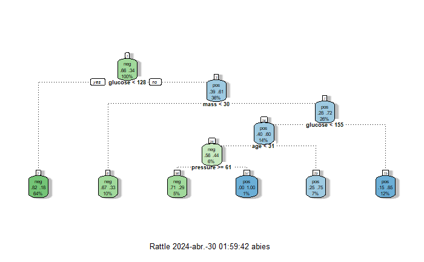

```r
fancyRpartPlot(Arbolp,type=2,digits = -2,box.palette = "RdYlBu",  # Paleta de colores para los nodos
                yesno = 1,split.cex = 1.1,cex=0.53)
```

ahora veremos el cp de nuestro árbol postpodado

```r
table2
```

```
          CP nsplit rel error    xerror       xstd
1 0.23300971      0 1.0000000 1.0000000 0.05679529
2 0.10679612      1 0.7669903 0.8058252 0.05342465
3 0.02103560      2 0.6601942 0.7378641 0.05191482
4 0.01747573      5 0.5970874 0.7330097 0.05179974
```

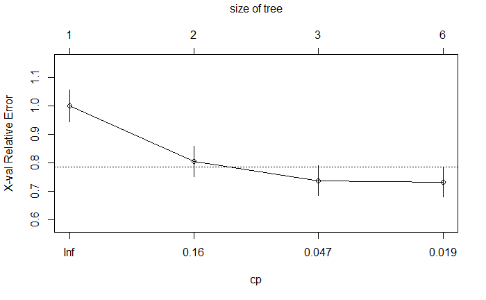

```r
plotcp(Arbolp)
```

```r
predic_arbolp<-predict(Arbolp,newdata = test,type="class")
table(predic_arbolp,test$diabetes)
```

```
predic_arbolp neg pos
          neg  83  30
          pos   9  32
```

Matriz de confusion de árbol de décision

```r
table(testpredic_arbol2,test$diabetes)
```

```
testpredic_arbol2 neg pos
              neg  76  22
              pos  16  40
```

Matriz de confusion de árbol de décision pre podado

```r
table(testpredic_arbol,test$diabetes)
```

```
testpredic_arbol neg pos
             neg  77  26
             pos  15  36
```

Matriz de confusion de árbol de décision post podado

```r
table(predic_arbolp,test$diabetes)
```

```
predic_arbolp neg pos
          neg  83  30
          pos   9  32
```